# Introduction to Choropleths

03/30/2020

## Choropleth Maps

A choropleth map is a map in which areas are shaded relative to a measurement such as population density. They are widely used, and quite useful, but one must be careful because

- regionally aggregated data can be misleading
- the use of counts or sums to represent magnitude rather than normalized values such as rates leads the eye giving incorrect weights to larger regions

Because of this, dasymetric maps are increasing popular. Nonetheless, choropleths are quite useful and have a nice implementation in R in the `choroplethr` package.

Here’s a very simple example, from the help file

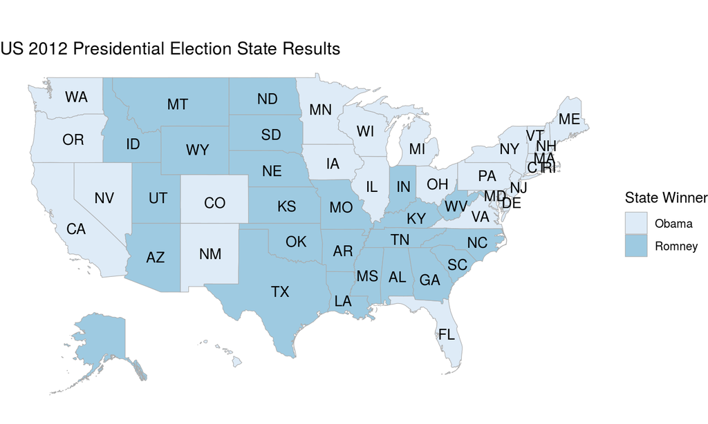

```r
library(choroplethr)
data(df_president)
state_choropleth(df_president,
                 title  = "US 2012 Presidential Election State Results",
                 legend = "State Winner")
```

- The only requirement is that the dataframe (`df_president` in this case) have two columns, `region` and `value`. The `region` value must exactly match the names of the states in the `state.map` dataframe (full lower case name).
- This requirement of the `choroplethr` functions (that the input is a data frame with specified names) makes the use of pipes an obvious choice

```r
head(df_president)
```

```
##       region  value
## 1    alabama Romney
## 2     alaska Romney
## 3    arizona Romney
## 4   arkansas Romney
## 5 california  Obama
## 6   colorado  Obama
```

There are also `country_choropleth()`, `admin1_choropleth()` (states or provinces), and `county_choropleth()`.

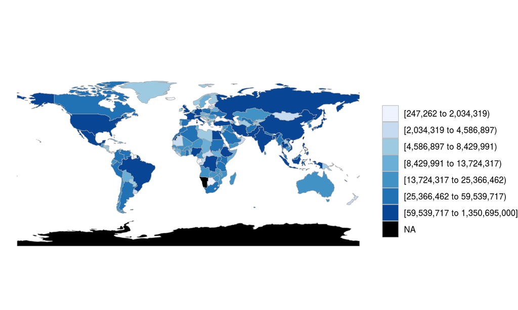

```r
data(df_pop_country)
country_choropleth(df_pop_country)
```

We’ll work through an example using `county_choropleth()`.

```r
data(df_county_demographics)
head(df_county_demographics, n = 2)
```

```
##   region total_population percent_white percent_black percent_asian
## 1   1001            54907            76            18             1
## 2   1003           187114            83             9             1
##   percent_hispanic per_capita_income median_rent median_age
## 1                2             24571         668       37.5
## 2                4             26766         693       41.5
```

Notice that counties are given by codes, not names. They are known as [county FIPS codes](https://en.wikipedia.org/wiki/FIPS_county_code)

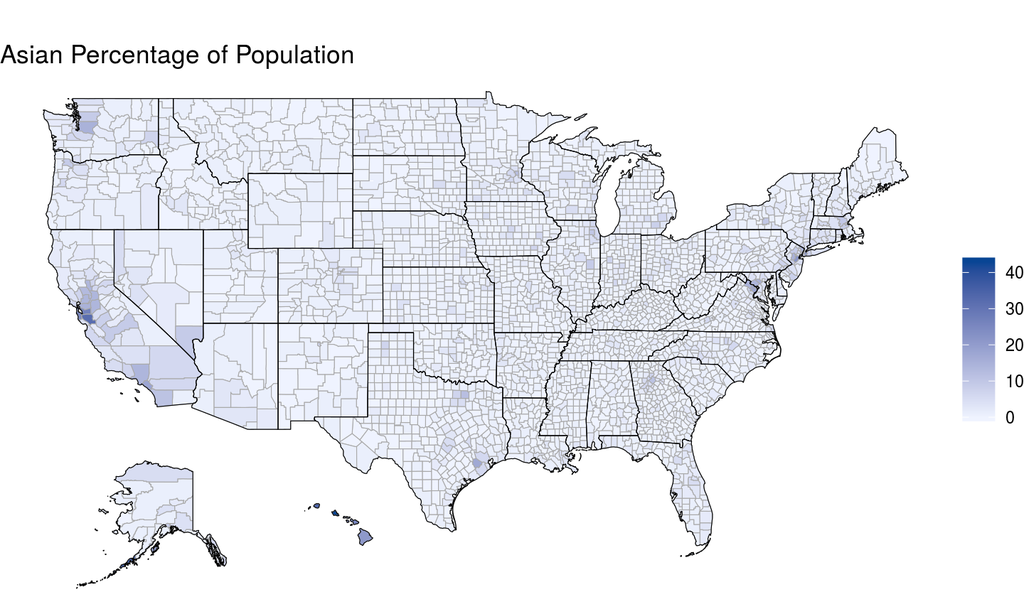

```r
df_county_demographics %>%
  dplyr::rename(value = percent_asian) %>%
  county_choropleth(title = "Asian Percentage of Population", num_colors = 1)
```

```r
# the num_colors = 1 option uses a continuous color palette
```

The color scheme in the map is so-so. There are a few counties with high proportions, leading the scale to be evenly distributed from 0 to 43, but almost all of the counties are in a very tight range.

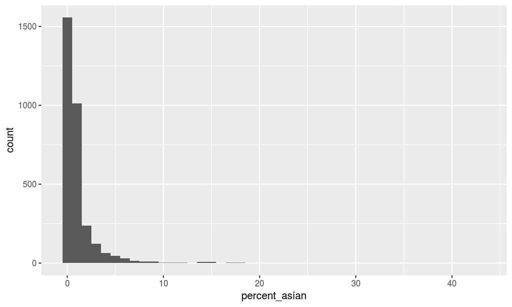

```r
ggplot(df_county_demographics, aes(percent_asian)) + geom_histogram(binwidth = 1)
```

```r
summary(df_county_demographics$percent_asian)
```

```
##    Min. 1st Qu.  Median    Mean 3rd Qu.    Max.
##   0.000   0.000   1.000   1.128   1.000  43.000
```

In this situation, it can be helpful to use a fixed number of colors which forces the choropleth function to bin the values.

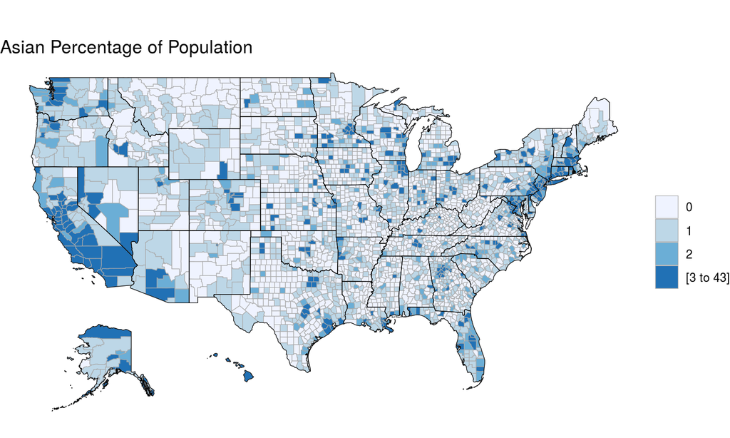

```r
df_county_demographics %>%
  dplyr::rename(value = percent_asian) %>%
  county_choropleth(title = "Asian Percentage of Population", num_colors = 9)
```

Let’s look at just NJ. Note the `state_zoom` option.

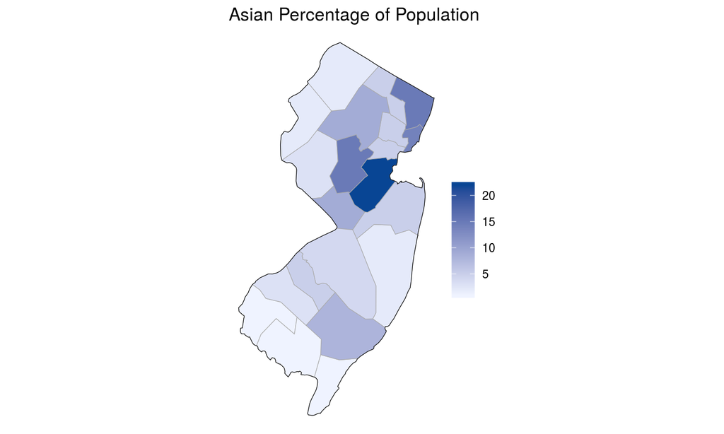

```r
df_county_demographics %>%
  dplyr::rename(value = percent_asian) %>%
  county_choropleth(title = "Asian Percentage of Population",
                    num_colors = 1, state_zoom = "new jersey")
```

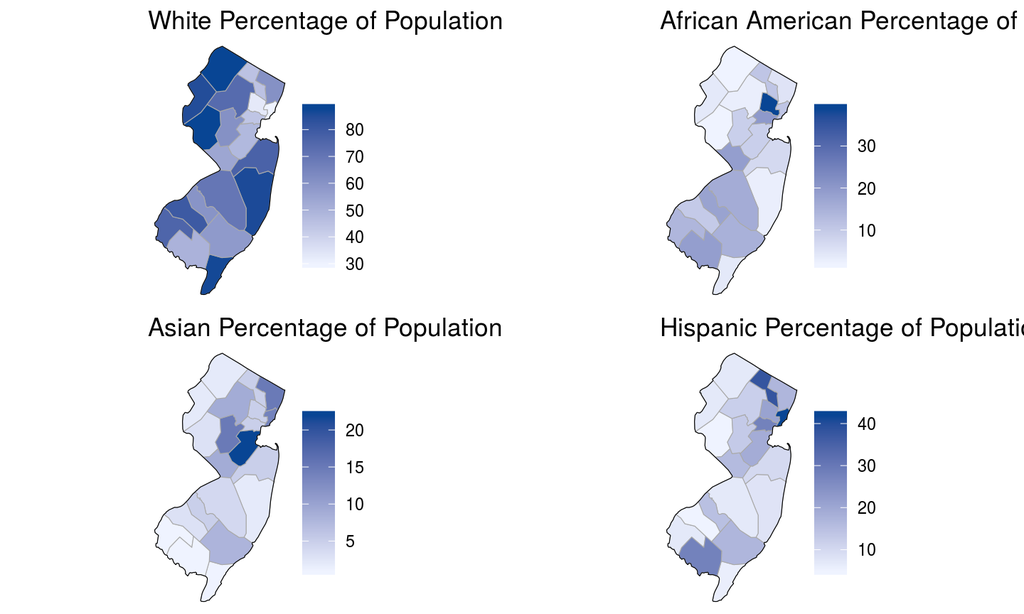

```r
library(gridExtra)
grid.arrange(
  df_county_demographics %>% dplyr::rename(value = percent_white) %>% county_choropleth(title = "White Percentage of Population", num_colors = 1, state_zoom = "new jersey"),
  df_county_demographics %>% dplyr::rename(value = percent_black) %>% county_choropleth(title = "African American Percentage of Population", num_colors = 1, state_zoom = "new jersey"),
  df_county_demographics %>% dplyr::rename(value = percent_asian) %>% county_choropleth(title = "Asian Percentage of Population", num_colors = 1, state_zoom = "new jersey"),
  df_county_demographics %>% dplyr::rename(value = percent_hispanic) %>% county_choropleth(title = "Hispanic Percentage of Population", num_colors = 1, state_zoom = "new jersey"),
  ncol=2, nrow=2
)
```

It’s possible to get finer control, but it requires some custom coding. (We’ll see some other approaches shortly.)

```r
library(viridis)
```

```r
temp_demo <- df_county_demographics %>%
  mutate(value = per_capita_income)
custom_choro <- CountyChoropleth$new(temp_demo)
custom_choro$title <- "Per Capita Income By County"
custom_choro$set_num_colors(1)
custom_choro$ggplot_polygon <- geom_polygon(aes(fill = value), color = NA)
custom_choro$ggplot_scale <- scale_fill_gradientn(name = "Per Capita Income", colours = viridis(32))
custom_choro$set_zoom("new jersey")
```

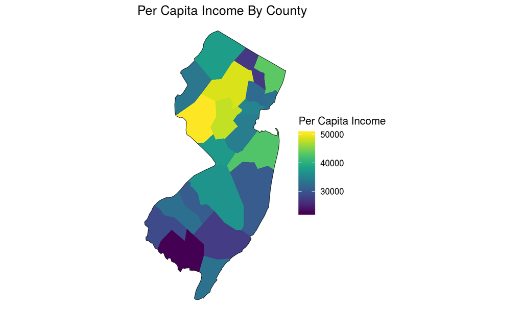

```r
custom_choro$render()
```

Note that for county-level data, the values for region are codes, not names. The are [FIPS county codes](https://en.wikipedia.org/wiki/FIPS_county_code). The first two digits correspond to the state, and are in fact the [FIPS state codes](https://en.wikipedia.org/wiki/Federal_Information_Processing_Standard_state_code).

```r
tail(df_county_demographics)
```

```
##      region total_population percent_white percent_black percent_asian
## 3138  56035            10178            86             0             1
## 3139  56037            44437            80             0             1
## 3140  56039            21575            82             0             1
## 3141  56041            21040            88             0             0
## 3142  56043             8468            83             0             1
## 3143  56045             7153            94             0             0
##      percent_hispanic per_capita_income median_rent median_age
## 3138                7             35944         979       37.9
## 3139               15             30517         789       33.2
## 3140               15             43444        1001       37.0
## 3141                9             25513         532       34.4
## 3142               14             28308         394       42.8
## 3143                3             28764         551       41.8
```

## In class exercise

1. Download the SPSS file “U.S. Religion Census Religious Congregations and Membership Study, 2010 (County File).SAV” from the class dropbox folder and read it into your R session. (There is a codebook [available](http://www.thearda.com/Archive/Files/Codebooks/RCMSCY10_CB.asp).)
2. The census contains information on adherents to 236 religious groups but also includes a few aggregate values. The county variable is called FIPS. Try making national and NJ choropleth maps of TOTRATE, the total rate of adherence (religious attendence per 1000 residents) and one of the aggregate rates:
- Evangelical Protestant–Rates of adherence per 1,000 population (2010) (EVANRATE)
- Black Protestant–Rates of adherence per 1,000 population (2010) (BPRTRATE)
- Mainline Protestant–Rates of adherence per 1,000 population (2010) (MPRTRATE)
- Catholic–Rates of adherence per 1,000 population (2010) (CATHRATE)
- Orthodox–Rates of adherence per 1,000 population (2010) (ORTHRATE)
- Other–Rates of adherence per 1,000 population (2010) (OTHRATE)